# How COVID19 Affected the flight of the USA

## Preliminary Wrangling

The dataset is about daily flights on USA on April-2019 and on April-2020 months only. The dataset comes from https://www.transtats.bts.gov

```python
# import all packages and set plots to be embedded inline
import numpy as np
import pandas as pd
import matplotlib.pyplot as plt
import seaborn as sb

%matplotlib inline
```

> Load in your dataset and describe its properties through the questions below. Try and motivate your exploration goals through this section.

```python
data_df = pd.read_csv('Flights_Reporting.csv')
data_df.head()
```

|  | YEAR | MONTH | DAY_OF_MONTH | DAY_OF_WEEK | FL_DATE | ORIGIN | DEST | DEP_DELAY | ARR_DELAY | CANCELLED | CANCELLATION_CODE | DIVERTED | AIR_TIME | DISTANCE | CARRIER_DELAY | WEATHER_DELAY | NAS_DELAY | SECURITY_DELAY | LATE_AIRCRAFT_DELAY |
| --- | --- | --- | --- | --- | --- | --- | --- | --- | --- | --- | --- | --- | --- | --- | --- | --- | --- | --- | --- |
| 0 | 2019 | 4 | 5 | 5 | 4/5/2019 | LGA | FLL | 11.0 | 4.0 | 0 | NaN | 0 | 146.0 | 1076 | NaN | NaN | NaN | NaN | NaN |
| 1 | 2019 | 4 | 6 | 6 | 4/6/2019 | LGA | FLL | -11.0 | -26.0 | 0 | NaN | 0 | 141.0 | 1076 | NaN | NaN | NaN | NaN | NaN |
| 2 | 2019 | 4 | 7 | 7 | 4/7/2019 | LGA | FLL | -8.0 | -14.0 | 0 | NaN | 0 | 148.0 | 1076 | NaN | NaN | NaN | NaN | NaN |
| 3 | 2019 | 4 | 8 | 1 | 4/8/2019 | LGA | FLL | 10.0 | 47.0 | 0 | NaN | 0 | 164.0 | 1076 | 0.0 | 0.0 | 47.0 | 0.0 | 0.0 |
| 4 | 2019 | 4 | 9 | 2 | 4/9/2019 | LGA | FLL | 66.0 | 85.0 | 0 | NaN | 0 | 159.0 | 1076 | 0.0 | 0.0 | 85.0 | 0.0 | 0.0 |

```python
data_df.shape
```

```
(925405, 19)
```

```python
data_df.duplicated().sum()
```

```
62761
```

```python
data_df.drop_duplicates(inplace=True)
```

```python
data_df.duplicated().sum()
```

```
0
```

```python
data_df.info()
```

```
<class 'pandas.core.frame.DataFrame'>
Int64Index: 862644 entries, 0 to 925402
Data columns (total 19 columns):
 #   Column               Non-Null Count   Dtype
---  ------               --------------   -----
 0   YEAR                 862644 non-null  int64
 1   MONTH                862644 non-null  int64
 2   DAY_OF_MONTH         862644 non-null  int64
 3   DAY_OF_WEEK          862644 non-null  int64
 4   FL_DATE              862644 non-null  object
 5   ORIGIN               862644 non-null  object
 6   DEST                 862644 non-null  object
 7   DEP_DELAY            780691 non-null  float64
 8   ARR_DELAY            778458 non-null  float64
 9   CANCELLED            862644 non-null  int64
 10  CANCELLATION_CODE    82376 non-null   object
 11  DIVERTED             862644 non-null  int64
 12  AIR_TIME             778458 non-null  float64
 13  DISTANCE             862644 non-null  int64
 14  CARRIER_DELAY        117554 non-null  float64
 15  WEATHER_DELAY        117554 non-null  float64
 16  NAS_DELAY            117554 non-null  float64
 17  SECURITY_DELAY       117554 non-null  float64
 18  LATE_AIRCRAFT_DELAY  117554 non-null  float64
dtypes: float64(8), int64(7), object(4)
memory usage: 118.5+ MB
```

```python
data_df.loc[data_df.CANCELLATION_CODE == "A", "CANCELLATION_CODE"] = "carrier"
data_df.loc[data_df.CANCELLATION_CODE == "B", "CANCELLATION_CODE"] = "weather"
data_df.loc[data_df.CANCELLATION_CODE == "C", "CANCELLATION_CODE"] = "NAS"
data_df.loc[data_df.CANCELLATION_CODE == "D", "CANCELLATION_CODE"] = "security"
```

```python
# Convert FL_DATE to datatime
data_df['FL_DATE'] = pd.to_datetime(data_df['FL_DATE'])
```

```python
# Convert CANCELLATION_CODE to category
data_df['CANCELLATION_CODE'] = data_df['CANCELLATION_CODE'].astype('category')
```

```python
# Convert YEAR, MONTH, DAY_OF_MONTH, DAY_OF_WEEK to string
data_df['YEAR'] =data_df['YEAR'].astype('str')
data_df['MONTH'] =data_df['MONTH'].astype('str')
data_df['DAY_OF_MONTH'] =data_df['DAY_OF_MONTH'].astype('str')
data_df['DAY_OF_WEEK'] =data_df['DAY_OF_WEEK'].astype('str')
```

```python
data_df.info()
```

```
<class 'pandas.core.frame.DataFrame'>
Int64Index: 862644 entries, 0 to 925402
Data columns (total 19 columns):
 #   Column               Non-Null Count   Dtype
---  ------               --------------   -----
 0   YEAR                 862644 non-null  object
 1   MONTH                862644 non-null  object
 2   DAY_OF_MONTH         862644 non-null  object
 3   DAY_OF_WEEK          862644 non-null  object
 4   FL_DATE              862644 non-null  datetime64[ns]
 5   ORIGIN               862644 non-null  object
 6   DEST                 862644 non-null  object
 7   DEP_DELAY            780691 non-null  float64
 8   ARR_DELAY            778458 non-null  float64
 9   CANCELLED            862644 non-null  int64
 10  CANCELLATION_CODE    82376 non-null   category
 11  DIVERTED             862644 non-null  int64
 12  AIR_TIME             778458 non-null  float64
 13  DISTANCE             862644 non-null  int64
 14  CARRIER_DELAY        117554 non-null  float64
 15  WEATHER_DELAY        117554 non-null  float64
 16  NAS_DELAY            117554 non-null  float64
 17  SECURITY_DELAY       117554 non-null  float64
 18  LATE_AIRCRAFT_DELAY  117554 non-null  float64
dtypes: category(1), datetime64[ns](1), float64(8), int64(3), object(6)
memory usage: 106.1+ MB
```

```python
# get the day of the flight from FL_DATE
data_df['day'] = data_df.FL_DATE.dt.strftime('%A')
```

```python
data_df.day.value_counts()
```

```
Monday       140506
Tuesday      133173
Thursday     128703
Wednesday    125483
Friday       121214
Sunday       114158
Saturday      99407
Name: day, dtype: int64
```

```python
data_df['CANCELLATION_CODE'].value_counts()
```

```
security    67278
carrier      7346
weather      6465
NAS          1287
Name: CANCELLATION_CODE, dtype: int64
```

```python
data_df.describe()
```

|  | DEP_DELAY | ARR_DELAY | CANCELLED | DIVERTED | AIR_TIME | DISTANCE | CARRIER_DELAY | WEATHER_DELAY | NAS_DELAY | SECURITY_DELAY | LATE_AIRCRAFT_DELAY |
| --- | --- | --- | --- | --- | --- | --- | --- | --- | --- | --- | --- |
| count | 780691.000000 | 778458.000000 | 862644.000000 | 862644.000000 | 778458.000000 | 862644.000000 | 117554.000000 | 117554.000000 | 117554.000000 | 117554.000000 | 117554.000000 |
| mean | 7.384298 | 0.521256 | 0.095492 | 0.002098 | 110.225203 | 786.683601 | 23.418863 | 3.836450 | 15.710899 | 0.090214 | 26.996895 |
| std | 44.579042 | 46.876120 | 0.293894 | 0.045758 | 69.096879 | 570.087634 | 67.729553 | 32.272452 | 39.389203 | 3.673522 | 52.867619 |
| min | -73.000000 | -110.000000 | 0.000000 | 0.000000 | 8.000000 | 31.000000 | 0.000000 | 0.000000 | 0.000000 | 0.000000 | 0.000000 |
| 25% | -7.000000 | -18.000000 | 0.000000 | 0.000000 | 60.000000 | 369.000000 | 0.000000 | 0.000000 | 0.000000 | 0.000000 | 0.000000 |
| 50% | -3.000000 | -9.000000 | 0.000000 | 0.000000 | 92.000000 | 634.000000 | 1.000000 | 0.000000 | 1.000000 | 0.000000 | 0.000000 |
| 75% | 2.000000 | 3.000000 | 0.000000 | 0.000000 | 140.000000 | 1023.000000 | 21.000000 | 0.000000 | 18.000000 | 0.000000 | 33.000000 |
| max | 2079.000000 | 2075.000000 | 1.000000 | 1.000000 | 696.000000 | 5095.000000 | 1768.000000 | 1410.000000 | 1418.000000 | 1048.000000 | 2014.000000 |

We can see some of the max value are outliers.

### What is the structure of your dataset?

The dataset contains 862,644 fligths with 19 variable. The dataset structure is the following:

#### 1- Airport

ORIGIN = Origin Airport

DEST = Destination Airport

#### 2- Trip info

FL_DATE = Fly Date

DAY_OF_WEEK = Number of day of the week (where 1 = Monday and 7 = Sunday)

DAY_OF_MONTH = number of day of the munth

AIR_TIME = Flight Time, in Minutes

DISTANCE = Distance between airports (miles)

DEP_DELAY = Difference in minutes between scheduled and actual departure time. Early departures show negative numbers.

ARR_DELAY = Difference in minutes between scheduled and actual arrival time. Early arrivals show negative numbers.

CARRIER_DELAY = Carrier Delay, in Minutes

WEATHER_DELAY = Weather Delay, in Minutes

NAS_DELAY = National Air System Delay, in Minutes

SECURITY_DELAY = Security Delay, in Minutes

LATE_AIRCRAFT_DELAY = Late Aircraft Delay, in Minutes

#### 4- Cancellations and Diversions

CANCELLED = Cancelled Flight Indicator (1=Yes)

CANCELLATION_CODE = Reason for Cancellation (A = carrier, B = weather, C = NAS, D = security)

DIVERTED = Diverted Flight Indicator (1=Yes)

### What is/are the main feature(s) of interest in your dataset?

The main feature of the dataset are:

YEAR: to determine if the flight was during COVID-19 (2020) or not.

DAY: to on which day the flight was, and determine which day has the most flights and least flights.

Cancellations and Diversions: Is Cancellations and Diversions during COVID-19 was more or less?

All delay variable: to see of COVID-19 make delay better or worse?

### What features in the dataset do you think will help support your investigation into your feature(s) of interest?

YEAR, DAY, CANCELLED, CANCELLATION_CODE, DIVERTED, all delay features.

## Univariate Exploration

[output not shown]

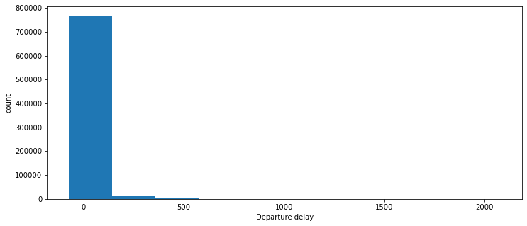

```python
plt.figure(figsize = [12, 5])
plt.hist(data= data_df , x = 'DEP_DELAY');
plt.ylabel('count');
plt.xlabel('Departure delay');
```

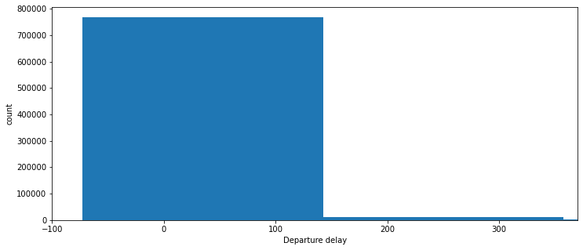

```python
# zoom in to privent outlirs
plt.figure(figsize = [12, 5])
plt.hist(data= data_df , x = 'DEP_DELAY',bins=10);
plt.xlim((-100,370));
plt.ylabel('count');
plt.xlabel('Departure delay');
```

We can see from the previos figure there is outliers of Departure delay. and i will remove any trip with Departure delay over 360 min.

```python
outliers= data_df[data_df.DEP_DELAY > 360] # save outliers before delete them.
```

```python
data_df.drop(data_df[data_df.DEP_DELAY > 360].index, inplace=True)
```

```python
data_df.to_csv('Flights_Reporting_Cleaned.csv',index=False) # save the cleaned dataset
outliers.to_csv('outliers.csv',index=False) # save outliers for future work.
```

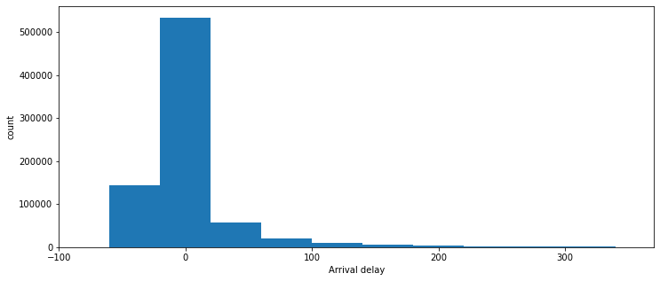

```python
plt.figure(figsize = [12, 5])
bins = np.arange(-100,data_df['ARR_DELAY'].max()+40,40)
plt.hist(data= data_df , x = 'ARR_DELAY',bins=bins);
plt.xlim((-100,370));
plt.ylabel('count');
plt.xlabel('Arrival delay');
```

Booth Arrival delay and Departure delay almost on the same interval (from -50 to 300). but we can see some values arrival delay start from -100 and up to about 330.

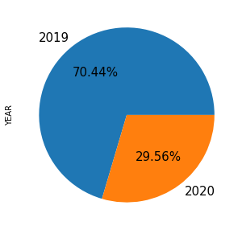

```python
plt.figure(figsize = [12, 5])
data_df.YEAR.value_counts().plot(kind='pie',fontsize =15, autopct='%1.2f%%');
```

We can see that 2019 has more fligh than 2020, Number of flights on 2019 is '606507' and number of flights on 2020 is '254516'.

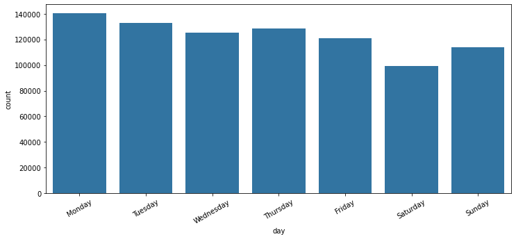

```python
plt.figure(figsize = [12, 5])
base_color = sb.color_palette()[0]
sb.countplot(data=data_df , x = 'day' , color = base_color , order = ['Monday','Tuesday','Wednesday','Thursday','Friday','Saturday','Sunday']);
plt.xticks(rotation = 30);
```

We can see the beginning of the week (Monday and Tuesday) has the highest flights, because a lot of people travel for the work.

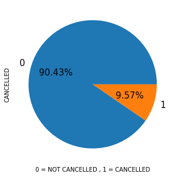

```python
plt.figure(figsize = [12, 5])
data_df.CANCELLED.value_counts().plot(kind='pie',fontsize =15, autopct='%1.2f%%');
plt.xlabel('0 = NOT CANCELLED , 1 = CANCELLED');
```

We can see only 9.57% of the flights was cancelled.

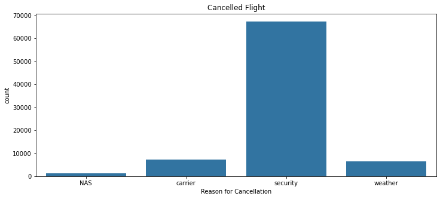

```python
plt.figure(figsize = [12, 5])
sb.countplot(data=data_df , x = 'CANCELLATION_CODE' , color=base_color);
plt.title('Cancelled Flight');
plt.xlabel('Reason for Cancellation');
```

The majorety of the cancelled flight was for security reason.

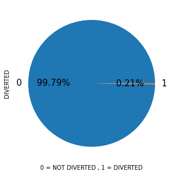

```python
plt.figure(figsize = [12, 5])
data_df.DIVERTED.value_counts().plot(kind='pie',fontsize =15, autopct='%1.2f%%');
plt.xlabel('0 = NOT DIVERTED , 1 = DIVERTED');
```

Only 0.21% of the flights was diverted.

### Discuss the distribution(s) of your variable(s) of interest. Were there any unusual points? Did you need to perform any transformations?

I made some clean to the dataset,and I have some very high values delays on some flight , I save these delay to new dataframe and remove it from the main dataframe (outliers).

### Of the features you investigated, were there any unusual distributions? Did you perform any operations on the data to tidy, adjust, or change the form of the data? If so, why did you do this?

I remove data contain Departure delay more than 360. and I change data tybe of some features, I also create new feautre 'day'.

## Bivariate Exploration

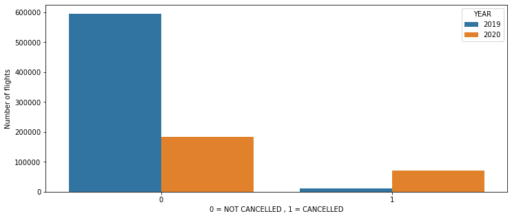

```python
plt.figure(figsize = [12, 5])
sb.countplot(data=data_df , x='CANCELLED' ,hue='YEAR' );
plt.xlabel('0 = NOT CANCELLED , 1 = CANCELLED');
plt.ylabel('Number of flights');
```

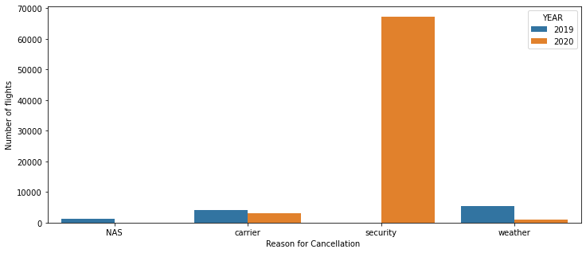

```python
plt.figure(figsize = [12, 5])
sb.countplot(data=data_df , x='CANCELLATION_CODE' ,hue='YEAR' );
plt.xlabel('Reason for Cancellation ');
plt.ylabel('Number of flights');
```

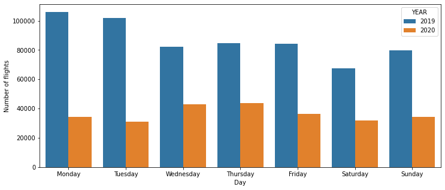

```python
plt.figure(figsize = [12, 5])
sb.countplot(data=data_df , x='day' ,hue='YEAR', order = ['Monday','Tuesday','Wednesday','Thursday','Friday','Saturday','Sunday']);
plt.xlabel('Day');
plt.ylabel('Number of flights');
```

In 2019 Monday and Tuesday was has the highest number of flights. In 2020 Wednesday and Thursday are the days with highest number of flights. maybe everyone wants to avoid crowding :).

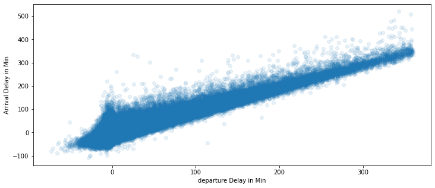

```python
plt.figure(figsize = [12, 5])
plt.scatter(data= data_df , x ='DEP_DELAY' , y ='ARR_DELAY',alpha=1/10);
plt.xlabel('departure Delay in Min');
plt.ylabel('Arrival Delay in Min');
```

This is obvious when the trip delay from departure Time it's will delay with almost the same time at arrival Time.

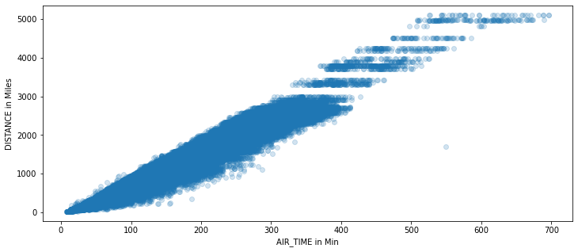

```python
plt.figure(figsize = [12, 5])
plt.scatter(data= data_df , x ='AIR_TIME' , y ='DISTANCE',alpha=1/5);
plt.xlabel('AIR_TIME in Min');
plt.ylabel('DISTANCE in Miles');
```

This is obvious when the trip has high air time the distance will be high. But there is one trip with distance about 1500 miles and it's take about 550 min !!! usually trip takes 550 min travel more than 4000 miles!.

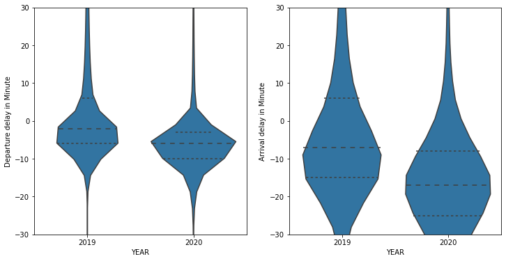

```python
plt.figure(figsize = [12, 6])
plt.subplot(1, 2, 1)
sb.violinplot(data=data_df, x='YEAR', y='DEP_DELAY',  color=base_color, inner='quartile');
plt.ylim((-30,30));
plt.xlabel('YEAR');
plt.ylabel('Departure delay in Minute');
plt.subplot(1, 2, 2)
sb.violinplot(data=data_df, x='YEAR', y='ARR_DELAY',  color=base_color, inner='quartile');
plt.ylim((-30,30));
plt.xlabel('YEAR');
plt.ylabel('Arrival delay in Minute');
```

We can see the performance in 2020 much better than 2019. in 2020 most of the flights has negative values for departure delay and arrival delay (negative numbers mean early departures and early arrivals

### Talk about some of the relationships you observed in this part of the investigation. How did the feature(s) of interest vary with other features in the dataset?

2020 has much more cancelled flights even though 2020 has much less flights

In 2019 Monday and Tuesday was has the highest number of flights. In 2020 Wednesday and Thursday are the days with highest number of flights.

The majority of the cancelled trip in 2020 was for security resaon.

When the trip has high air time the distance will be high.

The performance in 2020 much better than 2019

### Did you observe any interesting relationships between the other features (not the main feature(s) of interest)?

There is one trip with distance about 1500 miles and it's take about 550 min !!! usually trip takes 550 min travel more than 4000 miles!

## Multivariate Exploration

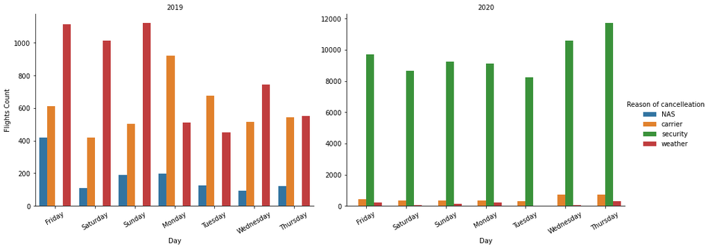

```python
My_figure=sb.catplot(data=data_df, x='day', col="YEAR", hue='CANCELLATION_CODE', kind='count', aspect=20/15,
                 sharey=False);
My_figure.set_xticklabels(rotation=30);
My_figure.set_axis_labels('Day', 'Flights Count');
My_figure._legend.set_title('Reason of cancelleation');
My_figure.set_titles('{col_name}');
```

### Talk about some of the relationships you observed in this part of the investigation. Were there features that strengthened each other in terms of looking at your feature(s) of interest?

We can see the reason for cancellation of the flights is very diffrent. non of 2019 flights was cancelled for security reason while in 2020 almost every flights was cancelled for security reason.

### Were there any interesting or surprising interactions between features?

Yes, There is no flight in 2019 cancelled for security reason.

## References

https://pandas.pydata.org/pandas-docs/stable/reference/api/pandas.DataFrame.plot.pie.html

https://matplotlib.org/3.1.1/api/legend_api.html

https://seaborn.pydata.org/generated/seaborn.catplot.html